# Week 3 Lab

4/15/2025

Instruction to work on this sheet: To evaluate the level of missingness in the `galo_miss` dataset run the code from steps 1-4, then answer subsequent exercise question. The dataset is available on the class website and can be accessed here: https://uo-educ-quant.github.io/645/data/galo.csv

GALO is a 1959 dataset that includes 1,382 sixth grade students in Groningen, Netherlands. The codebook is as follow -

- schid: School identification code
- female: an indicator for whether a student is female or now (0: male, 1: female)
- score: raw score on IQ test (original range 53 to 143)
- advice: schools advice to students (ordered categorical - coded 0 to 6; one of the 7 groups: No further education; Manual, including housekeeping; Agricultural; Extended primary education; General; Secondary school for girls; Pre-University.)
- medu: mother education (coded 1 to 9 representing some ordered groups)
- fedu: mother education (coded 1 to 9 representing some ordered groups)
- focc: father’s occupation (coded 1 to 6; one of the 6 groups: Lower white collar; Middle white collar; Professional, Managers; Shopkeepers; Schooled labor; Unskilled labor)

We might ask: What is the relationship between a teacher’s recommendation on secondary school choice and student’s IQ score? We are considering the advice variable as continuous for now.

## Topic: Missing Data

### Data

```r
#load libraries
library(tidyverse)
library(modelsummary)

## install some new packages if you already don't have these

# install.packages("missMethods")
# install.packages("mice")
library(missMethods)
library(mice)
```

```r
#load data from url
load(url("https://uo-educ-quant.github.io/645/data/galo_miss.RData"))

# The data is called galo_miss and shoud have popped up in the environment
head(galo_miss)
```

```
##   schid female score advice medu fedu focc
## 1     1      0    78     NA   NA    1   NA
## 2     1      1   104      4    3   NA   NA
## 3     1      0    93     NA    1    1   NA
## 4     1      1   114      4    1   NA   NA
## 5     1      1    NA     NA   NA   NA   NA
## 6     1      1    NA     NA   NA    1    2
```

```r
#let's re-factor some variables
galo_miss$female <- factor(galo_miss$female,
                         labels = c("Male", "Female"))
```

## 1. Evaluate levels of missingness

```r
# two-ways
summary(galo_miss)
```

```
##      schid          female        score           advice           medu
##  Min.   : 1.00   Male  :710   Min.   : 60.0   Min.   :2.000   Min.   :1.000
##  1st Qu.:16.25   Female:672   1st Qu.: 95.0   1st Qu.:4.000   1st Qu.:1.000
##  Median :30.00                Median :103.0   Median :4.000   Median :3.000
##  Mean   :30.02                Mean   :103.1   Mean   :4.024   Mean   :3.101
##  3rd Qu.:43.00                3rd Qu.:112.0   3rd Qu.:5.000   3rd Qu.:5.000
##  Max.   :58.00                Max.   :143.0   Max.   :6.000   Max.   :9.000
##                               NA's   :276     NA's   :553     NA's   :691
##       fedu            focc
##  Min.   :1.000   Min.   :1.000
##  1st Qu.:2.000   1st Qu.:2.000
##  Median :4.000   Median :3.000
##  Mean   :4.201   Mean   :3.357
##  3rd Qu.:6.000   3rd Qu.:5.000
##  Max.   :9.000   Max.   :6.000
##  NA's   :691     NA's   :691
```

```r
# Or use the missMethods package
missMethods::count_NA(galo_miss)
```

```
##  schid female  score advice   medu   fedu   focc
##      0      0    276    553    691    691    691
```

## 2. Plot the patterns and distributions of missing data in the `galo_miss` dataset.

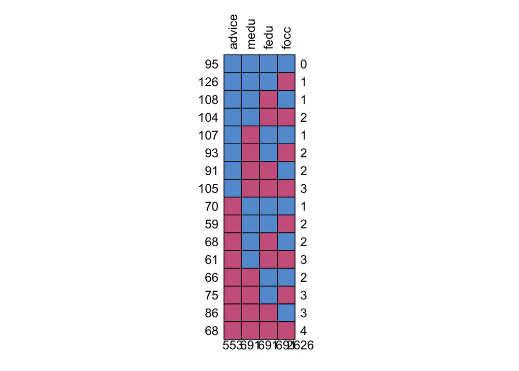

```
##     advice medu fedu focc
## 95       1    1    1    1    0
## 126      1    1    1    0    1
## 108      1    1    0    1    1
## 104      1    1    0    0    2
## 107      1    0    1    1    1
## 93       1    0    1    0    2
## 91       1    0    0    1    2
## 105      1    0    0    0    3
## 70       0    1    1    1    1
## 59       0    1    1    0    2
## 68       0    1    0    1    2
## 61       0    1    0    0    3
## 66       0    0    1    1    2
## 75       0    0    1    0    3
## 86       0    0    0    1    3
## 68       0    0    0    0    4
##        553  691  691  691 2626
```

```r
# Using the mice package
galo_miss %>%
  select(advice, medu, fedu, focc) %>%
  md.pattern(rotate.names = TRUE)
```

### 2.Q. Inspect missingness patterns. Fill this table as a start.

a. In how many observations is -

- 0 variables missing:
- 1 variable missing:
- 2 variables missing:
- 3 variables missing:
- 4 variables missing:
- advice missing:
- medu missing:
- fedu missing:
- focc missing:

b. What’s the top three common patterns of missingness?

c. What is your hunch on the type of missingness for the top three patterns. Is is a) completely at random; b) at random; c) or not random?

## 3. Impute missing data using mice and the cart imputation method

```r
# the first argument is the dataset,
# method tells which method of imputation to use: pmm or cart are common
# m tells how many imputed dataset to create: atleast 20 is good
# maxit is the number of iterations: at least 10 is good

galo_multi_cart <- mice(galo_miss, method = "cart", m = 20, maxit = 10)

# Adhoc: try to impute using pmm algorithm and see how different are the results, i.e., create a galo_multi_pmm
```

## 4. Visualize multiple imputation graphs

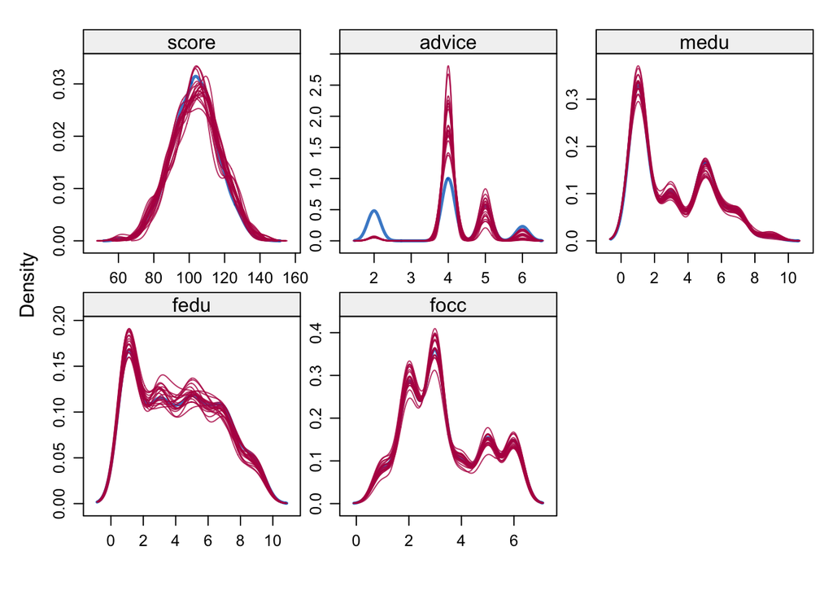

```r
densityplot(galo_multi_cart)
```

## 5. Compare estimates with listwide deletion and mice data

```r
#bivariate model with listwise deletion
lm_unconditional_listwise <- lm(advice ~ score, galo_miss)

#multivariate model with listwise deletion
lm_covariate_listwise <- lm(advice ~ score + female + medu + fedu + focc, galo_miss)

#bivariate model with multiply imputed dataset
mice_unconditional_listwise <- with(galo_multi_cart, lm(advice ~ score)) %>%
  pool()

#multivariate model with multiply imputed dataset
mice_covariate_listwise <- with(galo_multi_cart, lm(advice ~ score +
                              female + medu + fedu + focc)) %>%
  pool()

# Table
modelsummary(list("Bivariate listwise" = lm_unconditional_listwise,
                  "Multivariate listwise" = lm_covariate_listwise,
                  "Bivariate MICE" = mice_unconditional_listwise,
                  "Multivariate MICE" = mice_covariate_listwise),
             stars = TRUE,
             title = "...",
             notes = "...",
             gof_omit = "R2 Adj.|AIC|BIC|Log.Lik.|RMSE",
             coef_rename = c("score" = "IQ score") #can rename other things here too
             )
```

|  | Bivariate listwise | Multivariate listwise | Bivariate MICE | Multivariate MICE |
| --- | --- | --- | --- | --- |
| (Intercept) | −6.060*** | −6.108*** | 0.190 | 0.231 |
|  | (0.225) | (0.780) | (0.451) | (0.466) |
| IQ score | 0.092*** | 0.090*** | 0.038*** | 0.037*** |
|  | (0.002) | (0.007) | (0.004) | (0.004) |
| femaleFemale |  | −0.104 |  | −0.089+ |
|  |  | (0.151) |  | (0.051) |
| medu |  | 0.054 |  | 0.020 |
|  |  | (0.042) |  | (0.021) |
| fedu |  | −0.016 |  | −0.030 |
|  |  | (0.041) |  | (0.026) |
| focc |  | 0.048 |  | 0.046 |
|  |  | (0.070) |  | (0.038) |
| Num.Obs. | 665 | 76 | 1382 | 1382 |
| Num.Imp. |  |  | 20 | 20 |
| R2 | 0.754 | 0.754 | 0.230 | 0.238 |

+ p < 0.1, * p < 0.05, ** p < 0.01, *** p < 0.001  
…

### 5.Q. How does inference change across different methods? What are some tradeoffs here?